# Class Window

java.lang.Object

java.awt.Component

java.awt.Container

java.awt.Window

**All Implemented Interfaces:**

`ImageObserver, MenuContainer, Serializable, Accessible`

**Direct Known Subclasses:**

`BasicToolBarUI.DragWindow, Dialog, Frame, JWindow`

```java
public class Window extends Container implements Accessible
```

A `Window` object is a top-level window with no borders and no menubar. The default layout for a window is `BorderLayout`.

A window must have either a frame, dialog, or another window defined as its owner when it's constructed.

In a multi-screen environment, you can create a `Window` on a different screen device by constructing the `Window` with `Window(Window, GraphicsConfiguration)`. The `GraphicsConfiguration` object is one of the `GraphicsConfiguration` objects of the target screen device.

In a virtual device multi-screen environment in which the desktop area could span multiple physical screen devices, the bounds of all configurations are relative to the virtual device coordinate system. The origin of the virtual-coordinate system is at the upper left-hand corner of the primary physical screen. Depending on the location of the primary screen in the virtual device, negative coordinates are possible, as shown in the following figure.

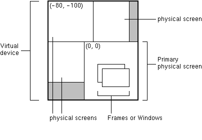

In such an environment, when calling `setLocation`, you must pass a virtual coordinate to this method. Similarly, calling `getLocationOnScreen` on a `Window` returns virtual device coordinates. Call the `getBounds` method of a `GraphicsConfiguration` to find its origin in the virtual coordinate system.

The following code sets the location of a `Window` at (10, 10) relative to the origin of the physical screen of the corresponding `GraphicsConfiguration`. If the bounds of the `GraphicsConfiguration` is not taken into account, the `Window` location would be set at (10, 10) relative to the virtual-coordinate system and would appear on the primary physical screen, which might be different from the physical screen of the specified `GraphicsConfiguration`.

```
     Window w = new Window(Window owner, GraphicsConfiguration gc);
     Rectangle bounds = gc.getBounds();
     w.setLocation(10 + bounds.x, 10 + bounds.y);
```

Note: the location and size of top-level windows (including `Window`s, `Frame`s, and `Dialog`s) are under the control of the desktop's window management system. Calls to `setLocation`, `setSize`, and `setBounds` are requests (not directives) which are forwarded to the window management system. Every effort will be made to honor such requests. However, in some cases the window management system may ignore such requests, or modify the requested geometry in order to place and size the `Window` in a way that more closely matches the desktop settings.

Visual effects such as halos, shadows, motion effects and animations may be applied to the window by the desktop window management system. These are outside the knowledge and control of the AWT and so for the purposes of this specification are not considered part of the top-level window.

Due to the asynchronous nature of native event handling, the results returned by `getBounds`, `getLocation`, `getLocationOnScreen`, and `getSize` might not reflect the actual geometry of the Window on screen until the last request has been processed. During the processing of subsequent requests these values might change accordingly while the window management system fulfills the requests.

An application may set the size and location of an invisible `Window` arbitrarily, but the window management system may subsequently change its size and/or location when the `Window` is made visible. One or more `ComponentEvent`s will be generated to indicate the new geometry.

Windows are capable of generating the following WindowEvents: WindowOpened, WindowClosed, WindowGainedFocus, WindowLostFocus.

**Since:**

1.0

**See Also:**

- `WindowEvent`
- `addWindowListener(WindowListener)`
- `BorderLayout`
- [Serialized Form](https://docs.oracle.com/en/java/javase/25/docs/api/serialized-form.html#java.awt.Window)

## Nested Class Summary

| Modifier and Type | Class | Description |
| --- | --- | --- |
| `protected class` | `Window.AccessibleAWTWindow` | This class implements accessibility support for the `Window` class. |
| `static enum` | `Window.Type` | Enumeration of available *window types*. |

### Nested classes/interfaces declared in class Container

`Container.AccessibleAWTContainer`

### Nested classes/interfaces declared in class Component

`Component.AccessibleAWTComponent, Component.BaselineResizeBehavior, Component.BltBufferStrategy, Component.FlipBufferStrategy`

## Field Summary

### Fields declared in class Component

`accessibleContext, BOTTOM_ALIGNMENT, CENTER_ALIGNMENT, LEFT_ALIGNMENT, RIGHT_ALIGNMENT, TOP_ALIGNMENT`

### Fields declared in interface ImageObserver

`ABORT, ALLBITS, ERROR, FRAMEBITS, HEIGHT, PROPERTIES, SOMEBITS, WIDTH`

## Constructor Summary

| Constructor | Description |
| --- | --- |
| `Window(Frame owner)` | Constructs a new, initially invisible window with the specified `Frame` as its owner. |
| `Window(Window owner)` | Constructs a new, initially invisible window with the specified `Window` as its owner. |
| Window(Window owner, GraphicsConfiguration gc) | Constructs a new, initially invisible window with the specified owner `Window` and a `GraphicsConfiguration` of a screen device. |

## Method Summary

| Modifier and Type | Method | Description |
| --- | --- | --- |
| `void` | `addNotify()` | Makes this Window displayable by creating the connection to its native screen resource. |
| `void` | `addPropertyChangeListener(PropertyChangeListener listener)` | Adds a PropertyChangeListener to the listener list. |
| `void` | addPropertyChangeListener(String propertyName, PropertyChangeListener listener) | Adds a PropertyChangeListener to the listener list for a specific property. |
| `void` | `addWindowFocusListener(WindowFocusListener l)` | Adds the specified window focus listener to receive window events from this window. |
| `void` | `addWindowListener(WindowListener l)` | Adds the specified window listener to receive window events from this window. |
| `void` | `addWindowStateListener(WindowStateListener l)` | Adds the specified window state listener to receive window events from this window. |
| `void` | `applyResourceBundle(String rbName)` | Deprecated. As of J2SE 1.4, replaced by `Component.applyComponentOrientation`. |
| `void` | `applyResourceBundle(ResourceBundle rb)` | Deprecated. As of J2SE 1.4, replaced by `Component.applyComponentOrientation`. |
| `void` | `createBufferStrategy(int numBuffers)` | Creates a new strategy for multi-buffering on this component. |
| `void` | createBufferStrategy(int numBuffers, BufferCapabilities caps) | Creates a new strategy for multi-buffering on this component with the required buffer capabilities. |
| `void` | `dispose()` | Releases all of the native screen resources used by this `Window`, its subcomponents, and all of its owned children. |
| `AccessibleContext` | `getAccessibleContext()` | Gets the AccessibleContext associated with this Window. |
| `Color` | `getBackground()` | Gets the background color of this window. |
| `BufferStrategy` | `getBufferStrategy()` | Returns the `BufferStrategy` used by this component. |
| `boolean` | `getFocusableWindowState()` | Returns whether this Window can become the focused Window if it meets the other requirements outlined in `isFocusableWindow`. |
| `final Container` | `getFocusCycleRootAncestor()` | Always returns `null` because Windows have no ancestors; they represent the top of the Component hierarchy. |
| `Component` | `getFocusOwner()` | Returns the child Component of this Window that has focus if this Window is focused; returns null otherwise. |
| `Set<AWTKeyStroke>` | `getFocusTraversalKeys(int id)` | Gets a focus traversal key for this Window. |
| `List<Image>` | `getIconImages()` | Returns the sequence of images to be displayed as the icon for this window. |
| `InputContext` | `getInputContext()` | Gets the input context for this window. |
| <T extends EventListener> T[] | `getListeners(Class<T> listenerType)` | Returns an array of all the objects currently registered as `FooListener`s upon this `Window`. |
| `Locale` | `getLocale()` | Gets the `Locale` object that is associated with this window, if the locale has been set. |
| `Dialog.ModalExclusionType` | `getModalExclusionType()` | Returns the modal exclusion type of this window. |
| `Component` | `getMostRecentFocusOwner()` | Returns the child Component of this Window that will receive the focus when this Window is focused. |
| `float` | `getOpacity()` | Returns the opacity of the window. |
| `Window[]` | `getOwnedWindows()` | Return an array containing all the windows this window currently owns. |
| `Window` | `getOwner()` | Returns the owner of this window. |
| `static Window[]` | `getOwnerlessWindows()` | Returns an array of all `Window`s created by this application that have no owner. |
| `Shape` | `getShape()` | Returns the shape of the window. |
| `Toolkit` | `getToolkit()` | Returns the toolkit of this frame. |

[output cut: 54 more lines]

### Methods declared in class Container

`add, add, add, add, add, addContainerListener, addImpl, applyComponentOrientation, areFocusTraversalKeysSet, countComponents, deliverEvent, doLayout, findComponentAt, findComponentAt, getAlignmentX, getAlignmentY, getComponent, getComponentAt, getComponentAt, getComponentCount, getComponents, getComponentZOrder, getContainerListeners, getFocusTraversalPolicy, getInsets, getLayout, getMaximumSize, getMinimumSize, getMousePosition, getPreferredSize, insets, invalidate, isAncestorOf, isFocusCycleRoot, isFocusTraversalPolicyProvider, isFocusTraversalPolicySet, layout, list, list, locate, minimumSize, paintComponents, paramString, preferredSize, print, printComponents, processContainerEvent, remove, remove, removeAll, removeContainerListener, removeNotify, setComponentZOrder, setFocusTraversalKeys, setFocusTraversalPolicy, setFocusTraversalPolicyProvider, setFont, setLayout, transferFocusDownCycle, update, validate, validateTree`

### Methods declared in class Component

`action, add, addComponentListener, addFocusListener, addHierarchyBoundsListener, addHierarchyListener, addInputMethodListener, addKeyListener, addMouseListener, addMouseMotionListener, addMouseWheelListener, bounds, checkImage, checkImage, coalesceEvents, contains, contains, createImage, createImage, createVolatileImage, createVolatileImage, disable, disableEvents, dispatchEvent, enable, enable, enableEvents, enableInputMethods, firePropertyChange, firePropertyChange, firePropertyChange, firePropertyChange, firePropertyChange, firePropertyChange, firePropertyChange, firePropertyChange, firePropertyChange, getBaseline, getBaselineResizeBehavior, getBounds, getBounds, getColorModel, getComponentListeners, getComponentOrientation, getCursor, getDropTarget, getFocusListeners, getFocusTraversalKeysEnabled, getFont, getFontMetrics, getForeground, getGraphics, getGraphicsConfiguration, getHeight, getHierarchyBoundsListeners, getHierarchyListeners, getIgnoreRepaint, getInputMethodListeners, getInputMethodRequests, getKeyListeners, getLocation, getLocation, getLocationOnScreen, getMouseListeners, getMouseMotionListeners, getMousePosition, getMouseWheelListeners, getName, getParent, getPropertyChangeListeners, getPropertyChangeListeners, getSize, getSize, getTreeLock, getWidth, getX, getY, gotFocus, handleEvent, hasFocus, imageUpdate, inside, isBackgroundSet, isCursorSet, isDisplayable, isDoubleBuffered, isEnabled, isFocusable, isFocusOwner, isFocusTraversable, isFontSet, isForegroundSet, isLightweight, isMaximumSizeSet, isMinimumSizeSet, isPreferredSizeSet, isValid, isVisible, keyDown, keyUp, list, list, list, location, lostFocus, mouseDown, mouseDrag, mouseEnter, mouseExit, mouseMove, mouseUp, move, nextFocus, paintAll, prepareImage, prepareImage, printAll, processComponentEvent, processFocusEvent, processHierarchyBoundsEvent, processHierarchyEvent, processInputMethodEvent, processKeyEvent, processMouseEvent, processMouseMotionEvent, processMouseWheelEvent, remove, removeComponentListener, removeFocusListener, removeHierarchyBoundsListener, removeHierarchyListener, removeInputMethodListener, removeKeyListener, removeMouseListener, removeMouseMotionListener, removeMouseWheelListener, removePropertyChangeListener, removePropertyChangeListener, repaint, repaint, repaint, repaint, requestFocus, requestFocus, requestFocus, requestFocus, requestFocusInWindow, requestFocusInWindow, requestFocusInWindow, resize, resize, revalidate, setComponentOrientation, setDropTarget, setEnabled, setFocusable, setFocusTraversalKeysEnabled, setForeground, setIgnoreRepaint, setLocale, setMaximumSize, setMixingCutoutShape, setName, setPreferredSize, show, size, toString, transferFocus, transferFocusBackward, transferFocusUpCycle`

### Methods declared in class Object

`clone, equals, finalize, getClass, hashCode, notify, notifyAll, wait, wait, wait`

## Constructor Details

### Window

```java
public Window(Frame owner)
```

Constructs a new, initially invisible window with the specified `Frame` as its owner. The window will not be focusable unless its owner is showing on the screen.

**Parameters:**

`owner` - the `Frame` to act as owner or `null` if this window has no owner

**Throws:**

`IllegalArgumentException` - if the `owner`'s `GraphicsConfiguration` is not from a screen device

`HeadlessException` - when `GraphicsEnvironment.isHeadless` returns `true`

**See Also:**

- `GraphicsEnvironment.isHeadless()`
- `isShowing()`

### Window

```java
public Window(Window owner)
```

Constructs a new, initially invisible window with the specified `Window` as its owner. This window will not be focusable unless its nearest owning `Frame` or `Dialog` is showing on the screen.

**Parameters:**

`owner` - the `Window` to act as owner or `null` if this window has no owner

**Throws:**

`IllegalArgumentException` - if the `owner`'s `GraphicsConfiguration` is not from a screen device

`HeadlessException` - when `GraphicsEnvironment.isHeadless()` returns `true`

**Since:**

1.2

**See Also:**

- `GraphicsEnvironment.isHeadless()`
- `isShowing()`

### Window

```java
public Window(Window owner, GraphicsConfiguration gc)
```

Constructs a new, initially invisible window with the specified owner `Window` and a `GraphicsConfiguration` of a screen device. The Window will not be focusable unless its nearest owning `Frame` or `Dialog` is showing on the screen.

**Parameters:**

`owner` - the window to act as owner or `null` if this window has no owner

`gc` - the `GraphicsConfiguration` of the target screen device; if `gc` is `null`, the system default `GraphicsConfiguration` is assumed

**Throws:**

`IllegalArgumentException` - if `gc` is not from a screen device

`HeadlessException` - when `GraphicsEnvironment.isHeadless()` returns `true`

**Since:**

1.3

**See Also:**

- `GraphicsEnvironment.isHeadless()`
- `GraphicsConfiguration.getBounds()`
- `isShowing()`

## Method Details

### getIconImages

```java
public List<Image> getIconImages()
```

Returns the sequence of images to be displayed as the icon for this window.

This method returns a copy of the internally stored list, so all operations on the returned object will not affect the window's behavior.

**Returns:**

the copy of icon images' list for this window, or empty list if this window doesn't have icon images.

**Since:**

1.6

**See Also:**

- `setIconImages(List)`
- `setIconImage(Image)`

### setIconImages

```java
public void setIconImages(List<? extends Image> icons)
```

Sets the sequence of images to be displayed as the icon for this window. Subsequent calls to `getIconImages` will always return a copy of the `icons` list.

Depending on the platform capabilities one or several images of different dimensions will be used as the window's icon.

The `icons` list can contain `MultiResolutionImage` images also. Suitable image depending on screen resolution is extracted from base `MultiResolutionImage` image and added to the icons list while base resolution image is removed from list. The `icons` list is scanned for the images of most appropriate dimensions from the beginning. If the list contains several images of the same size, the first will be used.

Ownerless windows with no icon specified use platform-default icon. The icon of an owned window may be inherited from the owner unless explicitly overridden. Setting the icon to `null` or empty list restores the default behavior.

Note : Native windowing systems may use different images of differing dimensions to represent a window, depending on the context (e.g. window decoration, window list, taskbar, etc.). They could also use just a single image for all contexts or no image at all.

**Parameters:**

`icons` - the list of icon images to be displayed.

**Since:**

1.6

**See Also:**

- `getIconImages()`
- `setIconImage(Image)`

### setIconImage

```java
public void setIconImage(Image image)
```

Sets the image to be displayed as the icon for this window.

This method can be used instead of `setIconImages()` to specify a single image as a window's icon.

The following statement:

```
    setIconImage(image);
```

is equivalent to:

```
    ArrayList<Image> imageList = new ArrayList<Image>();
    imageList.add(image);
    setIconImages(imageList);
```

Note : Native windowing systems may use different images of differing dimensions to represent a window, depending on the context (e.g. window decoration, window list, taskbar, etc.). They could also use just a single image for all contexts or no image at all.

**Parameters:**

`image` - the icon image to be displayed.

**Since:**

1.6

**See Also:**

- `setIconImages(List)`
- `getIconImages()`

### addNotify

```java
public void addNotify()
```

Makes this Window displayable by creating the connection to its native screen resource. This method is called internally by the toolkit and should not be called directly by programs.

**Overrides:**

`addNotify` in class `Container`

**Since:**

1.0

**See Also:**

- `Component.isDisplayable()`
- `Container.removeNotify()`

### pack

```java
public void pack()
```

Causes this Window to be sized to fit the preferred size and layouts of its subcomponents. The resulting width and height of the window are automatically enlarged if either of dimensions is less than the minimum size as specified by the previous call to the `setMinimumSize` method.

If the window and/or its owner are not displayable yet, both of them are made displayable before calculating the preferred size. The Window is validated after its size is being calculated.

**See Also:**

- `Component.isDisplayable()`
- `setMinimumSize(Dimension)`

### setMinimumSize

```java
public void setMinimumSize(Dimension minimumSize)
```

Sets the minimum size of this window to a constant value. Subsequent calls to `getMinimumSize` will always return this value. If current window's size is less than `minimumSize` the size of the window is automatically enlarged to honor the minimum size.

If the `setSize` or `setBounds` methods are called afterwards with a width or height less than that was specified by the `setMinimumSize` method the window is automatically enlarged to meet the `minimumSize` value. The `minimumSize` value also affects the behaviour of the `pack` method.

The default behavior is restored by setting the minimum size parameter to the `null` value.

Resizing operation may be restricted if the user tries to resize window below the `minimumSize` value. This behaviour is platform-dependent.

**Overrides:**

`setMinimumSize` in class `Component`

**Parameters:**

`minimumSize` - the new minimum size of this window

**Since:**

1.6

**See Also:**

- `Component.setMinimumSize(Dimension)`
- `Container.getMinimumSize()`
- `Component.isMinimumSizeSet()`
- `setSize(Dimension)`
- `pack()`

### setSize

```java
public void setSize(Dimension d)
```

Resizes this component so that it has width `d.width` and height `d.height`.

This method changes layout-related information, and therefore, invalidates the component hierarchy.

The `d.width` and `d.height` values are automatically enlarged if either is less than the minimum size as specified by previous call to `setMinimumSize`.

The method changes the geometry-related data. Therefore, the native windowing system may ignore such requests, or it may modify the requested data, so that the `Window` object is placed and sized in a way that corresponds closely to the desktop settings.

**Overrides:**

`setSize` in class `Component`

**Parameters:**

`d` - the dimension specifying the new size of this component

**Since:**

1.6

**See Also:**

- `Component.getSize()`
- `setBounds(int, int, int, int)`
- `setMinimumSize(Dimension)`

### setSize

```java
public void setSize(int width, int height)
```

Resizes this component so that it has width `width` and height `height`.

This method changes layout-related information, and therefore, invalidates the component hierarchy.

The `width` and `height` values are automatically enlarged if either is less than the minimum size as specified by previous call to `setMinimumSize`.

The method changes the geometry-related data. Therefore, the native windowing system may ignore such requests, or it may modify the requested data, so that the `Window` object is placed and sized in a way that corresponds closely to the desktop settings.

**Overrides:**

`setSize` in class `Component`

**Parameters:**

`width` - the new width of this component in pixels

`height` - the new height of this component in pixels

**Since:**

1.6

**See Also:**

- `Component.getSize()`
- `setBounds(int, int, int, int)`
- `setMinimumSize(Dimension)`

### setLocation

```java
public void setLocation(int x, int y)
```

Moves this component to a new location. The top-left corner of the new location is specified by the `x` and `y` parameters in the coordinate space of this component's parent.

This method changes layout-related information, and therefore, invalidates the component hierarchy.

The method changes the geometry-related data. Therefore, the native windowing system may ignore such requests, or it may modify the requested data, so that the `Window` object is placed and sized in a way that corresponds closely to the desktop settings.

**Overrides:**

`setLocation` in class `Component`

**Parameters:**

`x` - the *x*-coordinate of the new location's top-left corner in the parent's coordinate space

`y` - the *y*-coordinate of the new location's top-left corner in the parent's coordinate space

**See Also:**

- `Component.getLocation()`
- `Component.setBounds(int, int, int, int)`
- `Component.invalidate()`

### setLocation

```java
public void setLocation(Point p)
```

Moves this component to a new location. The top-left corner of the new location is specified by point `p`. Point `p` is given in the parent's coordinate space.

This method changes layout-related information, and therefore, invalidates the component hierarchy.

The method changes the geometry-related data. Therefore, the native windowing system may ignore such requests, or it may modify the requested data, so that the `Window` object is placed and sized in a way that corresponds closely to the desktop settings.

**Overrides:**

`setLocation` in class `Component`

**Parameters:**

`p` - the point defining the top-left corner of the new location, given in the coordinate space of this component's parent

**See Also:**

- `Component.getLocation()`
- `Component.setBounds(int, int, int, int)`
- `Component.invalidate()`

### reshape

```java
@Deprecated public void reshape(int x, int y, int width, int height)
```

Deprecated.

As of JDK version 1.1, replaced by `setBounds(int, int, int, int)`.

Description copied from class: `Component`

Reshapes the bounding rectangle for this component.

**Overrides:**

`reshape` in class `Component`

**Parameters:**

`x` - the *x* coordinate of the upper left corner of the rectangle

`y` - the *y* coordinate of the upper left corner of the rectangle

`width` - the width of the rectangle

`height` - the height of the rectangle

### setVisible

```java
public void setVisible(boolean b)
```

Shows or hides this `Window` depending on the value of parameter `b`.

If the method shows the window then the window is also made focused under the following conditions:

- The `Window` meets the requirements outlined in the `isFocusableWindow()` method.
- The `Window`'s `autoRequestFocus` property is of the `true` value.
- Native windowing system allows the `Window` to get focused.

There is an exception for the second condition (the value of the `autoRequestFocus` property). The property is not taken into account if the window is a modal dialog, which blocks the currently focused window.

Developers must never assume that the window is the focused or active window until it receives a WINDOW_GAINED_FOCUS or WINDOW_ACTIVATED event.

**Overrides:**

`setVisible` in class `Component`

**Parameters:**

`b` - if `true`, makes the `Window` visible, otherwise hides the `Window`. If the `Window` and/or its owner are not yet displayable, both are made displayable. The `Window` will be validated prior to being made visible. If the `Window` is already visible, this will bring the `Window` to the front.

If `false`, hides this `Window`, its subcomponents, and all of its owned children. The `Window` and its subcomponents can be made visible again with a call to `#setVisible(true)`.

**See Also:**

- `Component.isDisplayable()`
- `Component.setVisible(boolean)`
- `toFront()`
- `dispose()`
- `setAutoRequestFocus(boolean)`
- `isFocusableWindow()`

### show

```java
@Deprecated public void show()
```

Deprecated.

As of JDK version 1.5, replaced by `setVisible(boolean)`.

Makes the Window visible. If the Window and/or its owner are not yet displayable, both are made displayable. The Window will be validated prior to being made visible. If the Window is already visible, this will bring the Window to the front.

**Overrides:**

`show` in class `Component`

**See Also:**

- `Component.isDisplayable()`
- `toFront()`

### hide

```java
@Deprecated public void hide()
```

Deprecated.

As of JDK version 1.5, replaced by `setVisible(boolean)`.

Hide this Window, its subcomponents, and all of its owned children. The Window and its subcomponents can be made visible again with a call to `show`.

**Overrides:**

`hide` in class `Component`

**See Also:**

- `show()`
- `dispose()`

### dispose

```java
public void dispose()
```

Releases all of the native screen resources used by this `Window`, its subcomponents, and all of its owned children. That is, the resources for these `Component`s will be destroyed, any memory they consume will be returned to the OS, and they will be marked as undisplayable.

The `Window` and its subcomponents can be made displayable again by rebuilding the native resources with a subsequent call to `pack` or `show`. The states of the recreated `Window` and its subcomponents will be identical to the states of these objects at the point where the `Window` was disposed (not accounting for additional modifications between those actions).

**Note**: When the last displayable window within the Java virtual machine (VM) is disposed of, the VM may terminate. See [AWT Threading Issues](https://docs.oracle.com/en/java/javase/25/docs/api/java.desktop/java/awt/doc-files/AWTThreadIssues.html#Autoshutdown) for more information.

**See Also:**

- `Component.isDisplayable()`
- `pack()`
- `show()`

### toFront

```java
public void toFront()
```

If this Window is visible, brings this Window to the front and may make it the focused Window.

Places this Window at the top of the stacking order and shows it in front of any other Windows in this VM. No action will take place if this Window is not visible. Some platforms do not allow Windows which own other Windows to appear on top of those owned Windows. Some platforms may not permit this VM to place its Windows above windows of native applications, or Windows of other VMs. This permission may depend on whether a Window in this VM is already focused. Every attempt will be made to move this Window as high as possible in the stacking order; however, developers should not assume that this method will move this Window above all other windows in every situation.

Developers must never assume that this Window is the focused or active Window until this Window receives a WINDOW_GAINED_FOCUS or WINDOW_ACTIVATED event. On platforms where the top-most window is the focused window, this method will **probably** focus this Window (if it is not already focused) under the following conditions:

- The window meets the requirements outlined in the `isFocusableWindow()` method.
- The window's property `autoRequestFocus` is of the `true` value.
- Native windowing system allows the window to get focused.

On platforms where the stacking order does not typically affect the focused window, this method will **probably** leave the focused and active Windows unchanged.

If this method causes this Window to be focused, and this Window is a Frame or a Dialog, it will also become activated. If this Window is focused, but it is not a Frame or a Dialog, then the first Frame or Dialog that is an owner of this Window will be activated.

If this window is blocked by modal dialog, then the blocking dialog is brought to the front and remains above the blocked window.

**See Also:**

- `toBack()`
- `setAutoRequestFocus(boolean)`
- `isFocusableWindow()`

### toBack

```java
public void toBack()
```

If this Window is visible, sends this Window to the back and may cause it to lose focus or activation if it is the focused or active Window.

Places this Window at the bottom of the stacking order and shows it behind any other Windows in this VM. No action will take place is this Window is not visible. Some platforms do not allow Windows which are owned by other Windows to appear below their owners. Every attempt will be made to move this Window as low as possible in the stacking order; however, developers should not assume that this method will move this Window below all other windows in every situation.

Because of variations in native windowing systems, no guarantees about changes to the focused and active Windows can be made. Developers must never assume that this Window is no longer the focused or active Window until this Window receives a WINDOW_LOST_FOCUS or WINDOW_DEACTIVATED event. On platforms where the top-most window is the focused window, this method will **probably** cause this Window to lose focus. In that case, the next highest, focusable Window in this VM will receive focus. On platforms where the stacking order does not typically affect the focused window, this method will **probably** leave the focused and active Windows unchanged.

**See Also:**

- `toFront()`

### getToolkit

```java
public Toolkit getToolkit()
```

Returns the toolkit of this frame.

**Overrides:**

`getToolkit` in class `Component`

**Returns:**

the toolkit of this window.

**See Also:**

- `Toolkit`
- `Toolkit.getDefaultToolkit()`
- `Component.getToolkit()`

### getWarningString

```java
@Deprecated(since="24", forRemoval=true) public final String getWarningString()
```

Deprecated, for removal: This API element is subject to removal in a future version.

since JDK 24

Gets the warning string that is displayed with this window.

Warning strings are no longer applicable, so this method always returns `null` and may be removed in a future release.

**Returns:**

null

### getLocale

```java
public Locale getLocale()
```

Gets the `Locale` object that is associated with this window, if the locale has been set. If no locale has been set, then the default locale is returned.

**Overrides:**

`getLocale` in class `Component`

**Returns:**

the locale that is set for this window.

**Since:**

1.1

**See Also:**

- `Locale`

### getInputContext

```java
public InputContext getInputContext()
```

Gets the input context for this window. A window always has an input context, which is shared by subcomponents unless they create and set their own.

**Overrides:**

`getInputContext` in class `Component`

**Returns:**

the input context used by this component; `null` if no context can be determined

**Since:**

1.2

**See Also:**

- `Component.getInputContext()`

### setCursor

```java
public void setCursor(Cursor cursor)
```

Set the cursor image to a specified cursor.

The method may have no visual effect if the Java platform implementation and/or the native system do not support changing the mouse cursor shape.

**Overrides:**

`setCursor` in class `Component`

**Parameters:**

`cursor` - One of the constants defined by the `Cursor` class. If this parameter is null then the cursor for this window will be set to the type Cursor.DEFAULT_CURSOR.

**Since:**

1.1

**See Also:**

- `Component.getCursor()`
- `Cursor`

### getOwner

```java
public Window getOwner()
```

Returns the owner of this window.

**Returns:**

the owner of this window

**Since:**

1.2

### getOwnedWindows

```java
public Window[] getOwnedWindows()
```

Return an array containing all the windows this window currently owns.

**Returns:**

the array of all the owned windows

**Since:**

1.2

### getWindows

```java
public static Window[] getWindows()
```

Returns an array of all `Window`s, both owned and ownerless, created by this application. If called from an applet, the array includes only the `Window`s accessible by that applet.

**Warning:** this method may return system created windows, such as a print dialog. Applications should not assume the existence of these dialogs, nor should an application assume anything about these dialogs such as component positions, `LayoutManager`s or serialization.

**Returns:**

the array of all the `Window`s created by the application

**Since:**

1.6

**See Also:**

- `Frame.getFrames()`
- `getOwnerlessWindows()`

### getOwnerlessWindows

```java
public static Window[] getOwnerlessWindows()
```

Returns an array of all `Window`s created by this application that have no owner. They include `Frame`s and ownerless `Dialog`s and `Window`s. If called from an applet, the array includes only the `Window`s accessible by that applet.

**Warning:** this method may return system created windows, such as a print dialog. Applications should not assume the existence of these dialogs, nor should an application assume anything about these dialogs such as component positions, `LayoutManager`s or serialization.

**Returns:**

the array of all the ownerless `Window`s created by this application

**Since:**

1.6

**See Also:**

- `Frame.getFrames()`
- `getWindows()`

### setModalExclusionType

```java
public void setModalExclusionType(Dialog.ModalExclusionType exclusionType)
```

Specifies the modal exclusion type for this window. If a window is modal excluded, it is not blocked by some modal dialogs. See `Dialog.ModalExclusionType` for possible modal exclusion types.

If the given type is not supported, `NO_EXCLUDE` is used.

Note: changing the modal exclusion type for a visible window may have no effect until it is hidden and then shown again.

**Parameters:**

`exclusionType` - the modal exclusion type for this window; a `null` value is equivalent to `NO_EXCLUDE`

**Since:**

1.6

**See Also:**

- `Dialog.ModalExclusionType`
- `getModalExclusionType()`
- `Toolkit.isModalExclusionTypeSupported(Dialog.ModalExclusionType)`

### getModalExclusionType

```java
public Dialog.ModalExclusionType getModalExclusionType()
```

Returns the modal exclusion type of this window.

**Returns:**

the modal exclusion type of this window

**Since:**

1.6

**See Also:**

- `Dialog.ModalExclusionType`
- `setModalExclusionType(Dialog.ModalExclusionType)`

### addWindowListener

```java
public void addWindowListener(WindowListener l)
```

Adds the specified window listener to receive window events from this window. If l is null, no exception is thrown and no action is performed.

Refer to [AWT Threading Issues](https://docs.oracle.com/en/java/javase/25/docs/api/java.desktop/java/awt/doc-files/AWTThreadIssues.html#ListenersThreads) for details on AWT's threading model.

**Parameters:**

`l` - the window listener

**See Also:**

- `removeWindowListener(WindowListener)`
- `getWindowListeners()`

### addWindowStateListener

```java
public void addWindowStateListener(WindowStateListener l)
```

Adds the specified window state listener to receive window events from this window. If `l` is `null`, no exception is thrown and no action is performed.

Refer to [AWT Threading Issues](https://docs.oracle.com/en/java/javase/25/docs/api/java.desktop/java/awt/doc-files/AWTThreadIssues.html#ListenersThreads) for details on AWT's threading model.

**Parameters:**

`l` - the window state listener

**Since:**

1.4

**See Also:**

- `removeWindowStateListener(WindowStateListener)`
- `getWindowStateListeners()`

### addWindowFocusListener

```java
public void addWindowFocusListener(WindowFocusListener l)
```

Adds the specified window focus listener to receive window events from this window. If l is null, no exception is thrown and no action is performed.

Refer to [AWT Threading Issues](https://docs.oracle.com/en/java/javase/25/docs/api/java.desktop/java/awt/doc-files/AWTThreadIssues.html#ListenersThreads) for details on AWT's threading model.

**Parameters:**

`l` - the window focus listener

**Since:**

1.4

**See Also:**

- `removeWindowFocusListener(WindowFocusListener)`
- `getWindowFocusListeners()`

### removeWindowListener

```java
public void removeWindowListener(WindowListener l)
```

Removes the specified window listener so that it no longer receives window events from this window. If l is null, no exception is thrown and no action is performed.

Refer to [AWT Threading Issues](https://docs.oracle.com/en/java/javase/25/docs/api/java.desktop/java/awt/doc-files/AWTThreadIssues.html#ListenersThreads) for details on AWT's threading model.

**Parameters:**

`l` - the window listener

**See Also:**

- `addWindowListener(WindowListener)`
- `getWindowListeners()`

### removeWindowStateListener

```java
public void removeWindowStateListener(WindowStateListener l)
```

Removes the specified window state listener so that it no longer receives window events from this window. If `l` is `null`, no exception is thrown and no action is performed.

Refer to [AWT Threading Issues](https://docs.oracle.com/en/java/javase/25/docs/api/java.desktop/java/awt/doc-files/AWTThreadIssues.html#ListenersThreads) for details on AWT's threading model.

**Parameters:**

`l` - the window state listener

**Since:**

1.4

**See Also:**

- `addWindowStateListener(WindowStateListener)`
- `getWindowStateListeners()`

### removeWindowFocusListener

```java
public void removeWindowFocusListener(WindowFocusListener l)
```

Removes the specified window focus listener so that it no longer receives window events from this window. If l is null, no exception is thrown and no action is performed.

Refer to [AWT Threading Issues](https://docs.oracle.com/en/java/javase/25/docs/api/java.desktop/java/awt/doc-files/AWTThreadIssues.html#ListenersThreads) for details on AWT's threading model.

**Parameters:**

`l` - the window focus listener

**Since:**

1.4

**See Also:**

- `addWindowFocusListener(WindowFocusListener)`
- `getWindowFocusListeners()`

### getWindowListeners

```java
public WindowListener[] getWindowListeners()
```

Returns an array of all the window listeners registered on this window.

**Returns:**

all of this window's `WindowListener`s or an empty array if no window listeners are currently registered

**Since:**

1.4

**See Also:**

- `addWindowListener(WindowListener)`
- `removeWindowListener(WindowListener)`

### getWindowFocusListeners

```java
public WindowFocusListener[] getWindowFocusListeners()
```

Returns an array of all the window focus listeners registered on this window.

**Returns:**

all of this window's `WindowFocusListener`s or an empty array if no window focus listeners are currently registered

**Since:**

1.4

**See Also:**

- `addWindowFocusListener(WindowFocusListener)`
- `removeWindowFocusListener(WindowFocusListener)`

### getWindowStateListeners

```java
public WindowStateListener[] getWindowStateListeners()
```

Returns an array of all the window state listeners registered on this window.

**Returns:**

all of this window's `WindowStateListener`s or an empty array if no window state listeners are currently registered

**Since:**

1.4

**See Also:**

- `addWindowStateListener(WindowStateListener)`
- `removeWindowStateListener(WindowStateListener)`

### getListeners

```java
public <T extends EventListener> T[] getListeners(Class<T> listenerType)
```

Returns an array of all the objects currently registered as `FooListener`s upon this `Window`. `FooListener`s are registered using the `addFooListener` method.

You can specify the `listenerType` argument with a class literal, such as `FooListener.class`. For example, you can query a `Window w` for its window listeners with the following code:

```
WindowListener[] wls = (WindowListener[])(w.getListeners(WindowListener.class));
```

If no such listeners exist, this method returns an empty array.

**Overrides:**

`getListeners` in class `Container`

**Type Parameters:**

`T` - the type of the listeners

**Parameters:**

`listenerType` - the type of listeners requested; this parameter should specify an interface that descends from `java.util.EventListener`

**Returns:**

an array of all objects registered as `FooListener`s on this window, or an empty array if no such listeners have been added

**Throws:**

`ClassCastException` - if `listenerType` doesn't specify a class or interface that implements `java.util.EventListener`

`NullPointerException` - if `listenerType` is `null`

**Since:**

1.3

**See Also:**

- `getWindowListeners()`

### processEvent

```java
protected void processEvent(AWTEvent e)
```

Processes events on this window. If the event is an `WindowEvent`, it invokes the `processWindowEvent` method, else it invokes its superclass's `processEvent`.

Note that if the event parameter is `null` the behavior is unspecified and may result in an exception.

**Overrides:**

`processEvent` in class `Container`

**Parameters:**

`e` - the event

**See Also:**

- `Component.processComponentEvent(ComponentEvent)`
- `Component.processFocusEvent(FocusEvent)`
- `Component.processKeyEvent(KeyEvent)`
- `Component.processMouseEvent(MouseEvent)`
- `Component.processMouseMotionEvent(MouseEvent)`
- `Component.processInputMethodEvent(InputMethodEvent)`
- `Component.processHierarchyEvent(HierarchyEvent)`
- `Component.processMouseWheelEvent(MouseWheelEvent)`

### processWindowEvent

```java
protected void processWindowEvent(WindowEvent e)
```

Processes window events occurring on this window by dispatching them to any registered WindowListener objects. NOTE: This method will not be called unless window events are enabled for this component; this happens when one of the following occurs:

- A WindowListener object is registered via `addWindowListener`
- Window events are enabled via `enableEvents`

Note that if the event parameter is `null` the behavior is unspecified and may result in an exception.

**Parameters:**

`e` - the window event

**See Also:**

- `Component.enableEvents(long)`

### processWindowFocusEvent

```java
protected void processWindowFocusEvent(WindowEvent e)
```

Processes window focus event occurring on this window by dispatching them to any registered WindowFocusListener objects. NOTE: this method will not be called unless window focus events are enabled for this window. This happens when one of the following occurs:

- a WindowFocusListener is registered via `addWindowFocusListener`
- Window focus events are enabled via `enableEvents`

Note that if the event parameter is `null` the behavior is unspecified and may result in an exception.

**Parameters:**

`e` - the window focus event

**Since:**

1.4

**See Also:**

- `Component.enableEvents(long)`

### processWindowStateEvent

```java
protected void processWindowStateEvent(WindowEvent e)
```

Processes window state event occurring on this window by dispatching them to any registered `WindowStateListener` objects. NOTE: this method will not be called unless window state events are enabled for this window. This happens when one of the following occurs:

- a `WindowStateListener` is registered via `addWindowStateListener`
- window state events are enabled via `enableEvents`

Note that if the event parameter is `null` the behavior is unspecified and may result in an exception.

**Parameters:**

`e` - the window state event

**Since:**

1.4

**See Also:**

- `Component.enableEvents(long)`

### setAlwaysOnTop

```java
public final void setAlwaysOnTop(boolean alwaysOnTop)
```

Sets whether this window should always be above other windows. If there are multiple always-on-top windows, their relative order is unspecified and platform dependent.

If some other window is already always-on-top then the relative order between these windows is unspecified (depends on platform). No window can be brought to be over the always-on-top window except maybe another always-on-top window.

All windows owned by an always-on-top window inherit this state and automatically become always-on-top. If a window ceases to be always-on-top, the windows that it owns will no longer be always-on-top. When an always-on-top window is sent `toBack`, its always-on-top state is set to `false`.

When this method is called on a window with a value of `true`, and the window is visible and the platform supports always-on-top for this window, the window is immediately brought forward, "sticking" it in the top-most position. If the window isn`t currently visible, this method sets the always-on-top state to `true` but does not bring the window forward. When the window is later shown, it will be always-on-top.

When this method is called on a window with a value of `false` the always-on-top state is set to normal. It may also cause an unspecified, platform-dependent change in the z-order of top-level windows, but other always-on-top windows will remain in top-most position. Calling this method with a value of `false` on a window that has a normal state has no effect.

**Note**: some platforms might not support always-on-top windows. To detect if always-on-top windows are supported by the current platform, use `Toolkit.isAlwaysOnTopSupported()` and `isAlwaysOnTopSupported()`. If always-on-top mode isn't supported for this window or this window's toolkit does not support always-on-top windows, calling this method has no effect.

**Parameters:**

`alwaysOnTop` - true if the window should always be above other windows

**Since:**

1.5

**See Also:**

- `isAlwaysOnTop()`
- `toFront()`
- `toBack()`
- `isAlwaysOnTopSupported()`
- `getToolkit()`
- `Toolkit.isAlwaysOnTopSupported()`

### isAlwaysOnTopSupported

```java
public boolean isAlwaysOnTopSupported()
```

Returns whether the always-on-top mode is supported for this window. Some platforms may not support always-on-top windows, some may support only some kinds of top-level windows; for example, a platform may not support always-on-top modal dialogs.

**Returns:**

`true`, if the always-on-top mode is supported for this window and this window's toolkit supports always-on-top windows, `false` otherwise

**Since:**

1.6

**See Also:**

- `setAlwaysOnTop(boolean)`
- `getToolkit()`
- `Toolkit.isAlwaysOnTopSupported()`

### isAlwaysOnTop

```java
public final boolean isAlwaysOnTop()
```

Returns whether this window is an always-on-top window.

**Returns:**

`true`, if the window is in always-on-top state, `false` otherwise

**Since:**

1.5

**See Also:**

- `setAlwaysOnTop(boolean)`

### getFocusOwner

```java
public Component getFocusOwner()
```

Returns the child Component of this Window that has focus if this Window is focused; returns null otherwise.

**Returns:**

the child Component with focus, or null if this Window is not focused

**See Also:**

- `getMostRecentFocusOwner()`
- `isFocused()`

### getMostRecentFocusOwner

```java
public Component getMostRecentFocusOwner()
```

Returns the child Component of this Window that will receive the focus when this Window is focused. If this Window is currently focused, this method returns the same Component as `getFocusOwner()`. If this Window is not focused, then the child Component that most recently requested focus will be returned. If no child Component has ever requested focus, and this is a focusable Window, then this Window's initial focusable Component is returned. If no child Component has ever requested focus, and this is a non-focusable Window, null is returned.

**Returns:**

the child Component that will receive focus when this Window is focused

**Since:**

1.4

**See Also:**

- `getFocusOwner()`
- `isFocused()`
- `isFocusableWindow()`

### isActive

```java
public boolean isActive()
```

Returns whether this Window is active. Only a Frame or a Dialog may be active. The native windowing system may denote the active Window or its children with special decorations, such as a highlighted title bar. The active Window is always either the focused Window, or the first Frame or Dialog that is an owner of the focused Window.

**Returns:**

whether this is the active Window.

**Since:**

1.4

**See Also:**

- `isFocused()`

### isFocused

```java
public boolean isFocused()
```

Returns whether this Window is focused. If there exists a focus owner, the focused Window is the Window that is, or contains, that focus owner. If there is no focus owner, then no Window is focused.

If the focused Window is a Frame or a Dialog it is also the active Window. Otherwise, the active Window is the first Frame or Dialog that is an owner of the focused Window.

**Returns:**

whether this is the focused Window.

**Since:**

1.4

**See Also:**

- `isActive()`

### getFocusTraversalKeys

```java
public Set<AWTKeyStroke> getFocusTraversalKeys(int id)
```

Gets a focus traversal key for this Window. (See `setFocusTraversalKeys` for a full description of each key.)

If the traversal key has not been explicitly set for this Window, then this Window's parent's traversal key is returned. If the traversal key has not been explicitly set for any of this Window's ancestors, then the current KeyboardFocusManager's default traversal key is returned.

**Overrides:**

`getFocusTraversalKeys` in class `Container`

**Parameters:**

`id` - one of KeyboardFocusManager.FORWARD_TRAVERSAL_KEYS, KeyboardFocusManager.BACKWARD_TRAVERSAL_KEYS, KeyboardFocusManager.UP_CYCLE_TRAVERSAL_KEYS, or KeyboardFocusManager.DOWN_CYCLE_TRAVERSAL_KEYS

**Returns:**

the AWTKeyStroke for the specified key

**Throws:**

`IllegalArgumentException` - if id is not one of KeyboardFocusManager.FORWARD_TRAVERSAL_KEYS, KeyboardFocusManager.BACKWARD_TRAVERSAL_KEYS, KeyboardFocusManager.UP_CYCLE_TRAVERSAL_KEYS, or KeyboardFocusManager.DOWN_CYCLE_TRAVERSAL_KEYS

**Since:**

1.4

**See Also:**

- `Container.setFocusTraversalKeys(int, Set)`
- `KeyboardFocusManager.FORWARD_TRAVERSAL_KEYS`
- `KeyboardFocusManager.BACKWARD_TRAVERSAL_KEYS`
- `KeyboardFocusManager.UP_CYCLE_TRAVERSAL_KEYS`
- `KeyboardFocusManager.DOWN_CYCLE_TRAVERSAL_KEYS`

### setFocusCycleRoot

```java
public final void setFocusCycleRoot(boolean focusCycleRoot)
```

Does nothing because Windows must always be roots of a focus traversal cycle. The passed-in value is ignored.

**Overrides:**

`setFocusCycleRoot` in class `Container`

**Parameters:**

`focusCycleRoot` - this value is ignored

**Since:**

1.4

**See Also:**

- `isFocusCycleRoot()`
- `Container.setFocusTraversalPolicy(FocusTraversalPolicy)`
- `Container.getFocusTraversalPolicy()`

### isFocusCycleRoot

```java
public final boolean isFocusCycleRoot()
```

Always returns `true` because all Windows must be roots of a focus traversal cycle.

**Overrides:**

`isFocusCycleRoot` in class `Container`

**Returns:**

`true`

**Since:**

1.4

**See Also:**

- `setFocusCycleRoot(boolean)`
- `Container.setFocusTraversalPolicy(FocusTraversalPolicy)`
- `Container.getFocusTraversalPolicy()`

### getFocusCycleRootAncestor

```java
public final Container getFocusCycleRootAncestor()
```

Always returns `null` because Windows have no ancestors; they represent the top of the Component hierarchy.

**Overrides:**

`getFocusCycleRootAncestor` in class `Component`

**Returns:**

`null`

**Since:**

1.4

**See Also:**

- `Container.isFocusCycleRoot()`

### isFocusableWindow

```java
public final boolean isFocusableWindow()
```

Returns whether this Window can become the focused Window, that is, whether this Window or any of its subcomponents can become the focus owner. For a Frame or Dialog to be focusable, its focusable Window state must be set to `true`. For a Window which is not a Frame or Dialog to be focusable, its focusable Window state must be set to `true`, its nearest owning Frame or Dialog must be showing on the screen, and it must contain at least one Component in its focus traversal cycle. If any of these conditions is not met, then neither this Window nor any of its subcomponents can become the focus owner.

**Returns:**

`true` if this Window can be the focused Window; `false` otherwise

**Since:**

1.4

**See Also:**

- `getFocusableWindowState()`
- `setFocusableWindowState(boolean)`
- `isShowing()`
- `Component.isFocusable()`

### getFocusableWindowState

```java
public boolean getFocusableWindowState()
```

Returns whether this Window can become the focused Window if it meets the other requirements outlined in `isFocusableWindow`. If this method returns `false`, then `isFocusableWindow` will return `false` as well. If this method returns `true`, then `isFocusableWindow` may return `true` or `false` depending upon the other requirements which must be met in order for a Window to be focusable.

By default, all Windows have a focusable Window state of `true`.

**Returns:**

whether this Window can be the focused Window

**Since:**

1.4

**See Also:**

- `isFocusableWindow()`
- `setFocusableWindowState(boolean)`
- `isShowing()`
- `Component.setFocusable(boolean)`

### setFocusableWindowState

```java
public void setFocusableWindowState(boolean focusableWindowState)
```

Sets whether this Window can become the focused Window if it meets the other requirements outlined in `isFocusableWindow`. If this Window's focusable Window state is set to `false`, then `isFocusableWindow` will return `false`. If this Window's focusable Window state is set to `true`, then `isFocusableWindow` may return `true` or `false` depending upon the other requirements which must be met in order for a Window to be focusable.

Setting a Window's focusability state to `false` is the standard mechanism for an application to identify to the AWT a Window which will be used as a floating palette or toolbar, and thus should be a non-focusable Window. Setting the focusability state on a visible `Window` can have a delayed effect on some platforms — the actual change may happen only when the `Window` becomes hidden and then visible again. To ensure consistent behavior across platforms, set the `Window`'s focusable state when the `Window` is invisible and then show it.

**Parameters:**

`focusableWindowState` - whether this Window can be the focused Window

**Since:**

1.4

**See Also:**

- `isFocusableWindow()`
- `getFocusableWindowState()`
- `isShowing()`
- `Component.setFocusable(boolean)`

### setAutoRequestFocus

```java
public void setAutoRequestFocus(boolean autoRequestFocus)
```

Sets whether this window should receive focus on subsequently being shown (with a call to `setVisible(true)`), or being moved to the front (with a call to `toFront()`).

Note that `setVisible(true)` may be called indirectly (e.g. when showing an owner of the window makes the window to be shown). `toFront()` may also be called indirectly (e.g. when `setVisible(true)` is called on already visible window). In all such cases this property takes effect as well.

The value of the property is not inherited by owned windows.

**Parameters:**

`autoRequestFocus` - whether this window should be focused on subsequently being shown or being moved to the front

**Since:**

1.7

**See Also:**

- `isAutoRequestFocus()`
- `isFocusableWindow()`
- `setVisible(boolean)`
- `toFront()`

### isAutoRequestFocus

```java
public boolean isAutoRequestFocus()
```

Returns whether this window should receive focus on subsequently being shown (with a call to `setVisible(true)`), or being moved to the front (with a call to `toFront()`).

By default, the window has `autoRequestFocus` value of `true`.

**Returns:**

`autoRequestFocus` value

**Since:**

1.7

**See Also:**

- `setAutoRequestFocus(boolean)`

### addPropertyChangeListener

```java
public void addPropertyChangeListener(PropertyChangeListener listener)
```

Adds a PropertyChangeListener to the listener list. The listener is registered for all bound properties of this class, including the following:

- this Window's font ("font")
- this Window's background color ("background")
- this Window's foreground color ("foreground")
- this Window's focusability ("focusable")
- this Window's focus traversal keys enabled state ("focusTraversalKeysEnabled")
- this Window's Set of FORWARD_TRAVERSAL_KEYS ("forwardFocusTraversalKeys")
- this Window's Set of BACKWARD_TRAVERSAL_KEYS ("backwardFocusTraversalKeys")
- this Window's Set of UP_CYCLE_TRAVERSAL_KEYS ("upCycleFocusTraversalKeys")
- this Window's Set of DOWN_CYCLE_TRAVERSAL_KEYS ("downCycleFocusTraversalKeys")
- this Window's focus traversal policy ("focusTraversalPolicy")
- this Window's focusable Window state ("focusableWindowState")
- this Window's always-on-top state("alwaysOnTop")

Note that if this Window is inheriting a bound property, then no event will be fired in response to a change in the inherited property.

If listener is null, no exception is thrown and no action is performed.

**Overrides:**

`addPropertyChangeListener` in class `Container`

**Parameters:**

`listener` - the PropertyChangeListener to be added

**See Also:**

- `Component.removePropertyChangeListener(PropertyChangeListener)`
- `addPropertyChangeListener(java.lang.String,java.beans.PropertyChangeListener)`

### addPropertyChangeListener

```java
public void addPropertyChangeListener(String propertyName, PropertyChangeListener listener)
```

Adds a PropertyChangeListener to the listener list for a specific property. The specified property may be user-defined, or one of the following:

- this Window's font ("font")
- this Window's background color ("background")
- this Window's foreground color ("foreground")
- this Window's focusability ("focusable")
- this Window's focus traversal keys enabled state ("focusTraversalKeysEnabled")
- this Window's Set of FORWARD_TRAVERSAL_KEYS ("forwardFocusTraversalKeys")
- this Window's Set of BACKWARD_TRAVERSAL_KEYS ("backwardFocusTraversalKeys")
- this Window's Set of UP_CYCLE_TRAVERSAL_KEYS ("upCycleFocusTraversalKeys")
- this Window's Set of DOWN_CYCLE_TRAVERSAL_KEYS ("downCycleFocusTraversalKeys")
- this Window's focus traversal policy ("focusTraversalPolicy")
- this Window's focusable Window state ("focusableWindowState")
- this Window's always-on-top state("alwaysOnTop")

Note that if this Window is inheriting a bound property, then no event will be fired in response to a change in the inherited property.

If listener is null, no exception is thrown and no action is performed.

**Overrides:**

`addPropertyChangeListener` in class `Container`

**Parameters:**

`propertyName` - one of the property names listed above

`listener` - the PropertyChangeListener to be added

**See Also:**

- `addPropertyChangeListener(java.beans.PropertyChangeListener)`
- `Component.removePropertyChangeListener(PropertyChangeListener)`

### isValidateRoot

```java
public boolean isValidateRoot()
```

Indicates if this container is a validate root.

`Window` objects are the validate roots, and, therefore, they override this method to return `true`.

**Overrides:**

`isValidateRoot` in class `Container`

**Returns:**

`true`

**Since:**

1.7

**See Also:**

- `Container.isValidateRoot()`

### postEvent

```java
@Deprecated public boolean postEvent(Event e)
```

Deprecated.

As of JDK version 1.1 replaced by `dispatchEvent(AWTEvent)`.

Description copied from interface: `MenuContainer`

Posts an event to the listeners.

**Specified by:**

`postEvent` in interface `MenuContainer`

**Overrides:**

`postEvent` in class `Component`

**Parameters:**

`e` - the event to dispatch

**Returns:**

the results of posting the event

### isShowing

```java
public boolean isShowing()
```

Checks if this Window is showing on screen.

**Overrides:**

`isShowing` in class `Component`

**Returns:**

`true` if the component is showing, `false` otherwise

**See Also:**

- `Component.setVisible(boolean)`

### applyResourceBundle

```java
@Deprecated public void applyResourceBundle(ResourceBundle rb)
```

Deprecated.

As of J2SE 1.4, replaced by `Component.applyComponentOrientation`.

**Parameters:**

`rb` - the resource bundle

### applyResourceBundle

```java
@Deprecated public void applyResourceBundle(String rbName)
```

Deprecated.

As of J2SE 1.4, replaced by `Component.applyComponentOrientation`.

**Parameters:**

`rbName` - the resource name

### setType

```java
public void setType(Window.Type type)
```

Sets the type of the window. This method can only be called while the window is not displayable.

**Parameters:**

`type` - the window type

**Throws:**

`IllegalComponentStateException` - if the window is displayable.

`IllegalArgumentException` - if the type is `null`

**Since:**

1.7

**See Also:**

- `Component.isDisplayable()`
- `getType()`

### getType

```java
public Window.Type getType()
```

Returns the type of the window.

**Returns:**

the type of the window

**Since:**

1.7

**See Also:**

- `setType(Window.Type)`

### getAccessibleContext

```java
public AccessibleContext getAccessibleContext()
```

Gets the AccessibleContext associated with this Window. For windows, the AccessibleContext takes the form of an AccessibleAWTWindow. A new AccessibleAWTWindow instance is created if necessary.

**Specified by:**

`getAccessibleContext` in interface `Accessible`

**Overrides:**

`getAccessibleContext` in class `Component`

**Returns:**

an AccessibleAWTWindow that serves as the AccessibleContext of this Window

**Since:**

1.3

### setLocationRelativeTo

```java
public void setLocationRelativeTo(Component c)
```

Sets the location of the window relative to the specified component according to the following scenarios.

The target screen mentioned below is a screen to which the window should be placed after the setLocationRelativeTo method is called.

- If the component is `null`, or the `GraphicsConfiguration` associated with this component is `null`, the window is placed in the center of the screen. The center point can be obtained with the `GraphicsEnvironment.getCenterPoint` method.
- If the component is not `null`, but it is not currently showing, the window is placed in the center of the target screen defined by the `GraphicsConfiguration` associated with this component.
- If the component is not `null` and is shown on the screen, then the window is located in such a way that the center of the window coincides with the center of the component.

If the screens configuration does not allow the window to be moved from one screen to another, then the window is only placed at the location determined according to the above conditions and its `GraphicsConfiguration` is not changed.

**Note**: If the lower edge of the window is out of the screen, then the window is placed to the side of the `Component` that is closest to the center of the screen. So if the component is on the right part of the screen, the window is placed to its left, and vice versa.

If after the window location has been calculated, the upper, left, or right edge of the window is out of the screen, then the window is located in such a way that the upper, left, or right edge of the window coincides with the corresponding edge of the screen. If both left and right edges of the window are out of the screen, the window is placed at the left side of the screen. The similar placement will occur if both top and bottom edges are out of the screen. In that case, the window is placed at the top side of the screen.

The method changes the geometry-related data. Therefore, the native windowing system may ignore such requests, or it may modify the requested data, so that the `Window` object is placed and sized in a way that corresponds closely to the desktop settings.

**Parameters:**

`c` - the component in relation to which the window's location is determined

**Since:**

1.4

**See Also:**

- `GraphicsEnvironment.getCenterPoint()`

### createBufferStrategy

```java
public void createBufferStrategy(int numBuffers)
```

Creates a new strategy for multi-buffering on this component. Multi-buffering is useful for rendering performance. This method attempts to create the best strategy available with the number of buffers supplied. It will always create a `BufferStrategy` with that number of buffers. A page-flipping strategy is attempted first, then a blitting strategy using accelerated buffers. Finally, an unaccelerated blitting strategy is used.

Each time this method is called, the existing buffer strategy for this component is discarded.

**Parameters:**

`numBuffers` - number of buffers to create

**Throws:**

`IllegalArgumentException` - if numBuffers is less than 1.

`IllegalStateException` - if the component is not displayable

**Since:**

1.4

**See Also:**

- `Component.isDisplayable()`
- `getBufferStrategy()`

### createBufferStrategy

```java
public void createBufferStrategy(int numBuffers, BufferCapabilities caps) throws AWTException
```

Creates a new strategy for multi-buffering on this component with the required buffer capabilities. This is useful, for example, if only accelerated memory or page flipping is desired (as specified by the buffer capabilities).

Each time this method is called, the existing buffer strategy for this component is discarded.

**Parameters:**

`numBuffers` - number of buffers to create, including the front buffer

`caps` - the required capabilities for creating the buffer strategy; cannot be `null`

**Throws:**

`AWTException` - if the capabilities supplied could not be supported or met; this may happen, for example, if there is not enough accelerated memory currently available, or if page flipping is specified but not possible.

`IllegalArgumentException` - if numBuffers is less than 1, or if caps is `null`

**Since:**

1.4

**See Also:**

- `getBufferStrategy()`

### getBufferStrategy

```java
public BufferStrategy getBufferStrategy()
```

Returns the `BufferStrategy` used by this component. This method will return null if a `BufferStrategy` has not yet been created or has been disposed.

**Returns:**

the buffer strategy used by this component

**Since:**

1.4

**See Also:**

- `createBufferStrategy(int)`

### setLocationByPlatform

```java
public void setLocationByPlatform(boolean locationByPlatform)
```

Sets whether this Window should appear at the default location for the native windowing system or at the current location (returned by `getLocation`) the next time the Window is made visible. This behavior resembles a native window shown without programmatically setting its location. Most windowing systems cascade windows if their locations are not explicitly set. The actual location is determined once the window is shown on the screen.

This behavior can also be enabled by setting the System Property "java.awt.Window.locationByPlatform" to "true", though calls to this method take precedence.

Calls to `setVisible`, `setLocation` and `setBounds` after calling `setLocationByPlatform` clear this property of the Window.

For example, after the following code is executed:

```
setLocationByPlatform(true);
setVisible(true);
boolean flag = isLocationByPlatform();
```

The window will be shown at platform's default location and `flag` will be `false`.

In the following sample:

```
setLocationByPlatform(true);
setLocation(10, 10);
boolean flag = isLocationByPlatform();
setVisible(true);
```

The window will be shown at (10, 10) and `flag` will be `false`.

**Parameters:**

`locationByPlatform` - `true` if this Window should appear at the default location, `false` if at the current location

**Throws:**

`IllegalComponentStateException` - if the window is showing on screen and locationByPlatform is `true`.

**Since:**

1.5

**See Also:**

- `setLocation(int, int)`
- `isShowing()`
- `setVisible(boolean)`
- `isLocationByPlatform()`
- `System.getProperty(String)`

### isLocationByPlatform

```java
public boolean isLocationByPlatform()
```

Returns `true` if this Window will appear at the default location for the native windowing system the next time this Window is made visible. This method always returns `false` if the Window is showing on the screen.

**Returns:**

whether this Window will appear at the default location

**Since:**

1.5

**See Also:**

- `setLocationByPlatform(boolean)`
- `isShowing()`

### setBounds

```java
public void setBounds(int x, int y, int width, int height)
```

Moves and resizes this component. The new location of the top-left corner is specified by `x` and `y`, and the new size is specified by `width` and `height`.

This method changes layout-related information, and therefore, invalidates the component hierarchy.

The `width` or `height` values are automatically enlarged if either is less than the minimum size as specified by previous call to `setMinimumSize`.

The method changes the geometry-related data. Therefore, the native windowing system may ignore such requests, or it may modify the requested data, so that the `Window` object is placed and sized in a way that corresponds closely to the desktop settings.

**Overrides:**

`setBounds` in class `Component`

**Parameters:**

`x` - the new *x*-coordinate of this component

`y` - the new *y*-coordinate of this component

`width` - the new `width` of this component

`height` - the new `height` of this component

**Since:**

1.6

**See Also:**

- `Component.getBounds()`
- `setLocation(int, int)`
- `setLocation(Point)`
- `setSize(int, int)`
- `setSize(Dimension)`
- `setMinimumSize(Dimension)`
- `setLocationByPlatform(boolean)`
- `isLocationByPlatform()`

### setBounds

```java
public void setBounds(Rectangle r)
```

Moves and resizes this component to conform to the new bounding rectangle `r`. This component's new position is specified by `r.x` and `r.y`, and its new size is specified by `r.width` and `r.height`

This method changes layout-related information, and therefore, invalidates the component hierarchy.

The `r.width` or `r.height` values will be automatically enlarged if either is less than the minimum size as specified by previous call to `setMinimumSize`.

The method changes the geometry-related data. Therefore, the native windowing system may ignore such requests, or it may modify the requested data, so that the `Window` object is placed and sized in a way that corresponds closely to the desktop settings.

**Overrides:**

`setBounds` in class `Component`

**Parameters:**

`r` - the new bounding rectangle for this component

**Since:**

1.6

**See Also:**

- `Component.getBounds()`
- `setLocation(int, int)`
- `setLocation(Point)`
- `setSize(int, int)`
- `setSize(Dimension)`
- `setMinimumSize(Dimension)`
- `setLocationByPlatform(boolean)`
- `isLocationByPlatform()`

### getOpacity

```java
public float getOpacity()
```

Returns the opacity of the window.

**Returns:**

the opacity of the window

**Since:**

1.7

**See Also:**

- `setOpacity(float)`
- `GraphicsDevice.WindowTranslucency`

### setOpacity

```java
public void setOpacity(float opacity)
```

Sets the opacity of the window.

The opacity value is in the range [0..1]. Note that setting the opacity level of 0 may or may not disable the mouse event handling on this window. This is a platform-dependent behavior.

The following conditions must be met in order to set the opacity value less than `1.0f`:

- The `TRANSLUCENT` translucency must be supported by the underlying system
- The window must be undecorated (see `Frame.setUndecorated(boolean)` and `Dialog.setUndecorated(boolean)`)
- The window must not be in full-screen mode (see `GraphicsDevice.setFullScreenWindow(Window)`)

If the requested opacity value is less than `1.0f`, and any of the above conditions are not met, the window opacity will not change, and the `IllegalComponentStateException` will be thrown.

The translucency levels of individual pixels may also be effected by the alpha component of their color (see `setBackground(Color)`) and the current shape of this window (see `setShape(Shape)`).

**Parameters:**

`opacity` - the opacity level to set to the window

**Throws:**

`IllegalArgumentException` - if the opacity is out of the range [0..1]

`IllegalComponentStateException` - if the window is decorated and the opacity is less than `1.0f`

`IllegalComponentStateException` - if the window is in full screen mode, and the opacity is less than `1.0f`

`UnsupportedOperationException` - if the `GraphicsDevice.WindowTranslucency#TRANSLUCENT TRANSLUCENT` translucency is not supported and the opacity is less than `1.0f`

**Since:**

1.7

**See Also:**

- `getOpacity()`
- `setBackground(Color)`
- `setShape(Shape)`
- `Frame.isUndecorated()`
- `Dialog.isUndecorated()`
- `GraphicsDevice.WindowTranslucency`
- `GraphicsDevice.isWindowTranslucencySupported(GraphicsDevice.WindowTranslucency)`

### getShape

```java
public Shape getShape()
```

Returns the shape of the window. The value returned by this method may not be the same as previously set with `setShape(shape)`, but it is guaranteed to represent the same shape.

**Returns:**

the shape of the window or `null` if no shape is specified for the window

**Since:**

1.7

**See Also:**

- `setShape(Shape)`
- `GraphicsDevice.WindowTranslucency`

### setShape

```java
public void setShape(Shape shape)
```

Sets the shape of the window.

Setting a shape cuts off some parts of the window. Only the parts that belong to the given `Shape` remain visible and clickable. If the shape argument is `null`, this method restores the default shape, making the window rectangular on most platforms.

The following conditions must be met to set a non-null shape:

- The `PERPIXEL_TRANSPARENT` translucency must be supported by the underlying system
- The window must be undecorated (see `Frame.setUndecorated(boolean)` and `Dialog.setUndecorated(boolean)`)
- The window must not be in full-screen mode (see `GraphicsDevice.setFullScreenWindow(Window)`)

If the requested shape is not `null`, and any of the above conditions are not met, the shape of this window will not change, and either the `UnsupportedOperationException` or `IllegalComponentStateException` will be thrown.

The translucency levels of individual pixels may also be effected by the alpha component of their color (see `setBackground(Color)`) and the opacity value (see `setOpacity(float)`). See `GraphicsDevice.WindowTranslucency` for more details.

**Parameters:**

`shape` - the shape to set to the window

**Throws:**

`IllegalComponentStateException` - if the shape is not `null` and the window is decorated

`IllegalComponentStateException` - if the shape is not `null` and the window is in full-screen mode

`UnsupportedOperationException` - if the shape is not `null` and `PERPIXEL_TRANSPARENT` translucency is not supported

**Since:**

1.7

**See Also:**

- `getShape()`
- `setBackground(Color)`
- `setOpacity(float)`
- `Frame.isUndecorated()`
- `Dialog.isUndecorated()`
- `GraphicsDevice.WindowTranslucency`
- `GraphicsDevice.isWindowTranslucencySupported(GraphicsDevice.WindowTranslucency)`

### getBackground

```java
public Color getBackground()
```

Gets the background color of this window.

Note that the alpha component of the returned color indicates whether the window is in the non-opaque (per-pixel translucent) mode.

**Overrides:**

`getBackground` in class `Component`

**Returns:**

this component's background color

**See Also:**

- `setBackground(Color)`
- `isOpaque()`
- `GraphicsDevice.WindowTranslucency`

### setBackground

```java
public void setBackground(Color bgColor)
```

Sets the background color of this window.

If the windowing system supports the `PERPIXEL_TRANSLUCENT` translucency, the alpha component of the given background color may effect the mode of operation for this window: it indicates whether this window must be opaque (alpha equals `1.0f`) or per-pixel translucent (alpha is less than `1.0f`). If the given background color is `null`, the window is considered completely opaque.

All the following conditions must be met to enable the per-pixel transparency mode for this window:

- The `PERPIXEL_TRANSLUCENT` translucency must be supported by the graphics device where this window is located
- The window must be undecorated (see `Frame.setUndecorated(boolean)` and `Dialog.setUndecorated(boolean)`)
- The window must not be in full-screen mode (see `GraphicsDevice.setFullScreenWindow(Window)`)

If the alpha component of the requested background color is less than `1.0f`, and any of the above conditions are not met, the background color of this window will not change, the alpha component of the given background color will not affect the mode of operation for this window, and either the `UnsupportedOperationException` or `IllegalComponentStateException` will be thrown.

When the window is per-pixel translucent, the drawing sub-system respects the alpha value of each individual pixel. If a pixel gets painted with the alpha color component equal to zero, it becomes visually transparent. If the alpha of the pixel is equal to 1.0f, the pixel is fully opaque. Interim values of the alpha color component make the pixel semi-transparent. In this mode, the background of the window gets painted with the alpha value of the given background color. If the alpha value of the argument of this method is equal to `0`, the background is not painted at all.

The actual level of translucency of a given pixel also depends on window opacity (see `setOpacity(float)`), as well as the current shape of this window (see `setShape(Shape)`).

Note that painting a pixel with the alpha value of `0` may or may not disable the mouse event handling on this pixel. This is a platform-dependent behavior. To make sure the mouse events do not get dispatched to a particular pixel, the pixel must be excluded from the shape of the window.

Enabling the per-pixel translucency mode may change the graphics configuration of this window due to the native platform requirements.

**Overrides:**

`setBackground` in class `Component`

**Parameters:**

`bgColor` - the color to become this window's background color.

**Throws:**

`IllegalComponentStateException` - if the alpha value of the given background color is less than `1.0f` and the window is decorated

`IllegalComponentStateException` - if the alpha value of the given background color is less than `1.0f` and the window is in full-screen mode

`UnsupportedOperationException` - if the alpha value of the given background color is less than `1.0f` and `PERPIXEL_TRANSLUCENT` translucency is not supported

**See Also:**

- `getBackground()`
- `isOpaque()`
- `setOpacity(float)`
- `setShape(Shape)`
- `Frame.isUndecorated()`
- `Dialog.isUndecorated()`
- `GraphicsDevice.WindowTranslucency`
- `GraphicsDevice.isWindowTranslucencySupported(GraphicsDevice.WindowTranslucency)`
- `GraphicsConfiguration.isTranslucencyCapable()`

### isOpaque

```java
public boolean isOpaque()
```

Indicates if the window is currently opaque.

The method returns `false` if the background color of the window is not `null` and the alpha component of the color is less than `1.0f`. The method returns `true` otherwise.

**Overrides:**

`isOpaque` in class `Component`

**Returns:**

`true` if the window is opaque, `false` otherwise

**Since:**

1.7

**See Also:**

- `getBackground()`
- `setBackground(Color)`

### paint

```java
public void paint(Graphics g)
```

Paints the container. This forwards the paint to any lightweight components that are children of this container. If this method is reimplemented, super.paint(g) should be called so that lightweight components are properly rendered. If a child component is entirely clipped by the current clipping setting in g, paint() will not be forwarded to that child.

**Overrides:**

`paint` in class `Container`

**Parameters:**

`g` - the specified Graphics window

**Since:**

1.7

**See Also:**

- `Component.update(Graphics)`